# Permutation Tests

In the permutation test, positive values from BVA for same time-windows were extracted, corresponding to the area of ipsi-contra rather than contra-ipsi. These values are transformed to the negative (*-1) and combined with original samples to a combined 42 or 34 negative values, respective of experiment. Then, 100k samples size 21 or 17 (depending on the experiment) are drawn from the combined pools. If left/right position of channel (contra/ipsi target-channel relationship) is meaningful, then observed value should be in the higher 5% of the distribution of permuted means. The dashed line marks the probability of the original mean within the distribution of permuted means. The number next to the line shows the probability of the original mean within the distribution of permuted means.

RLpcN: Experiment 1 - probability of < 5% was found for the Lateral Target and No Distractor conditions following a neutral cue in both segments. Experiment 2 - in the first segment, probability of < 5% was found for the Lateral Target and Salient Target conditions following a neutral cue (Lateral Target following a valid cue = 0.06). In the second segment, probability of < 5% was found for all conditions following a valid cue and for the No Distractor and Salient Target conditions following a neutral cue (Lateral Target = 0.06)

permutation tests - SPCN experiment 1

```
## $`SPCN, Lateral Target, Valid Cue`
```

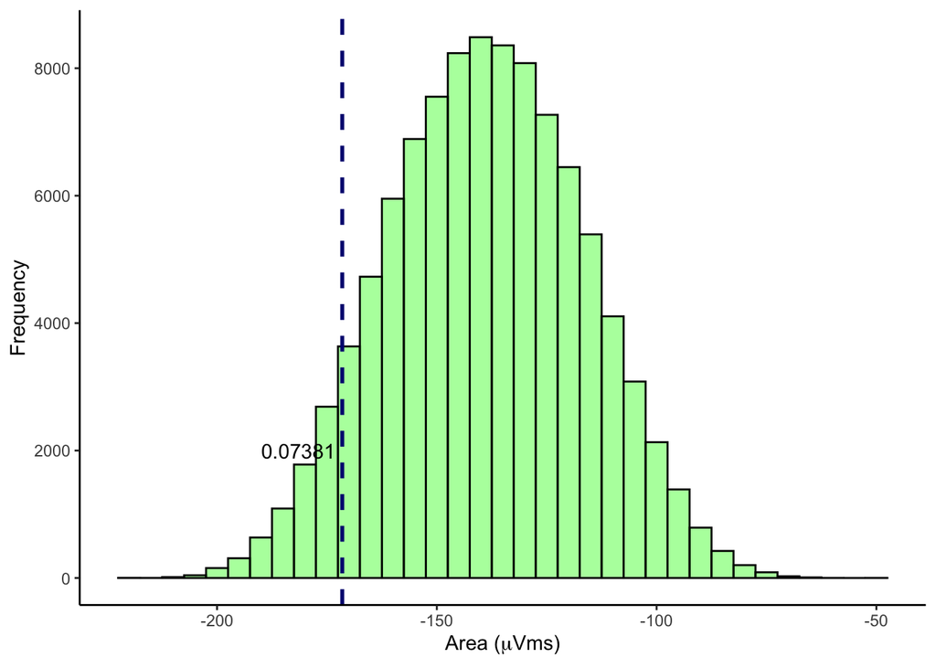

```
##
## $`SPCN, No Distractor, Valid Cue`
```

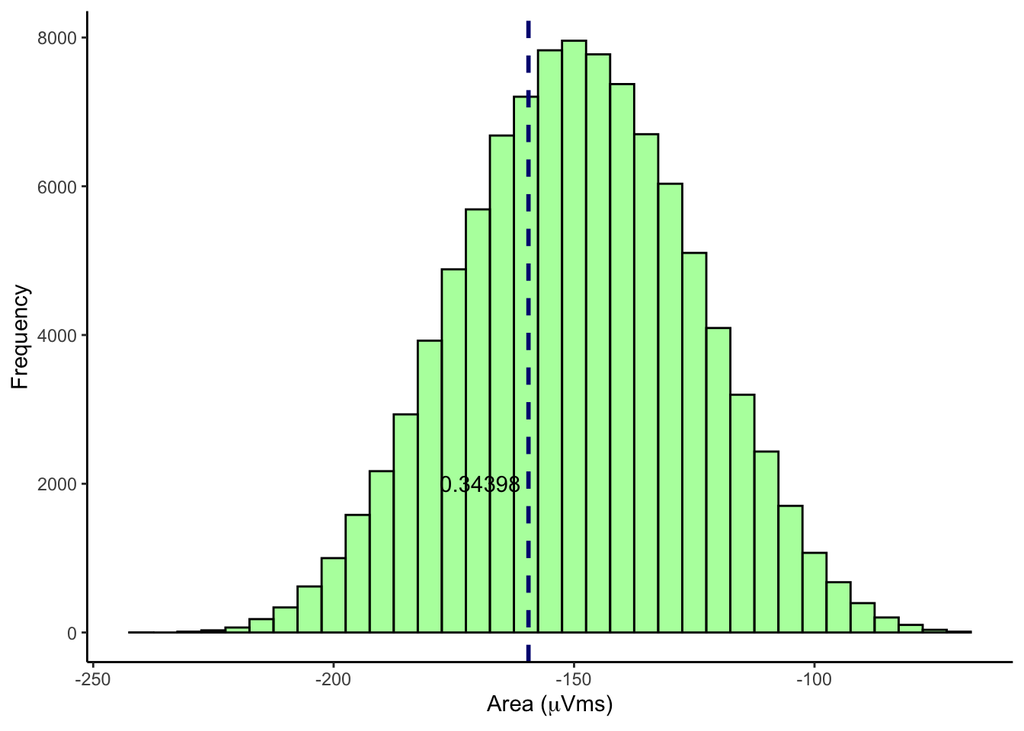

```
##
## $`SPCN, Salient Target, Valid Cue`
```

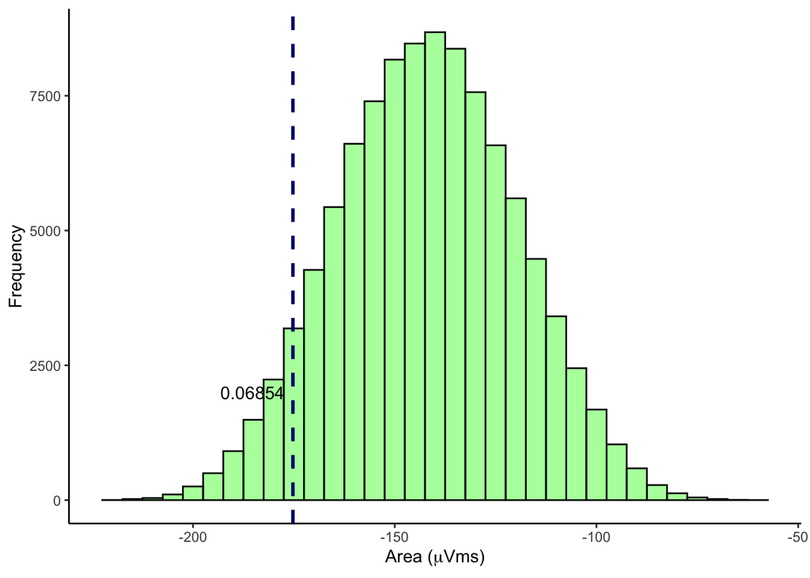

```
##
## $`SPCN, Lateral Target, Neutral Cue`
```

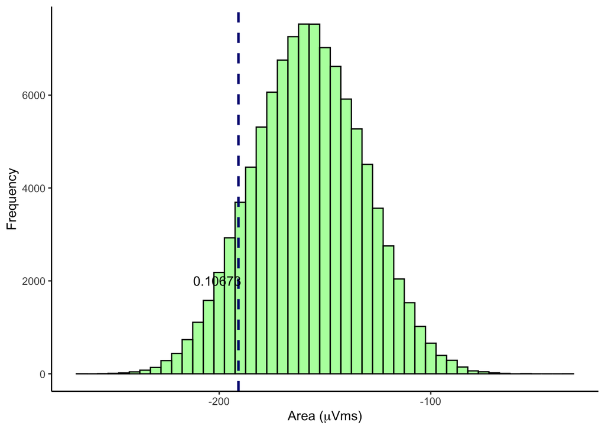

```
##
## $`SPCN, No Distractor, Neutral Cue`
```

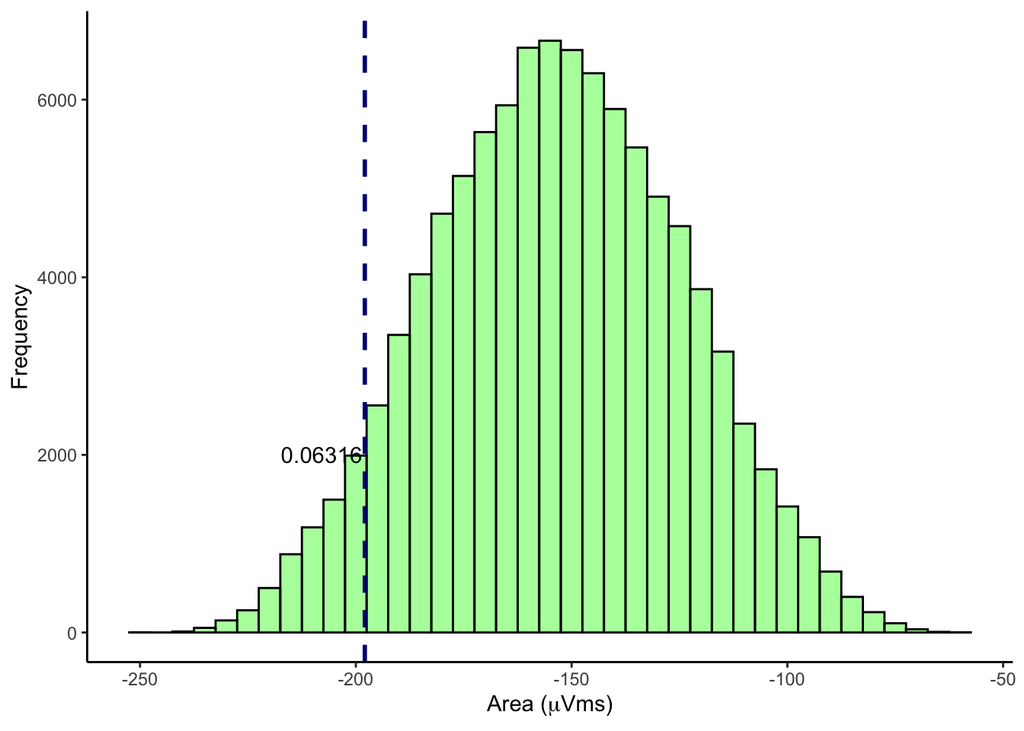

```
##
## $`SPCN, Salient Target, Neutral Cue`
```

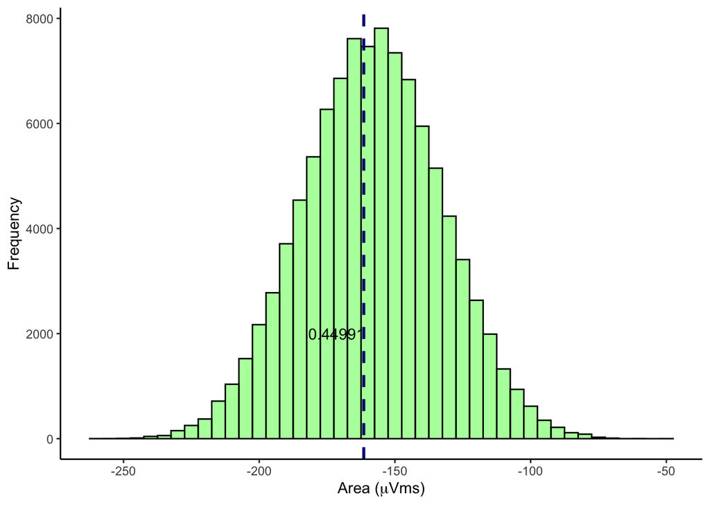

permutation tests - SPCN experiment 2

```
## $`SPCN, Lateral Target, Valid Cue`
```

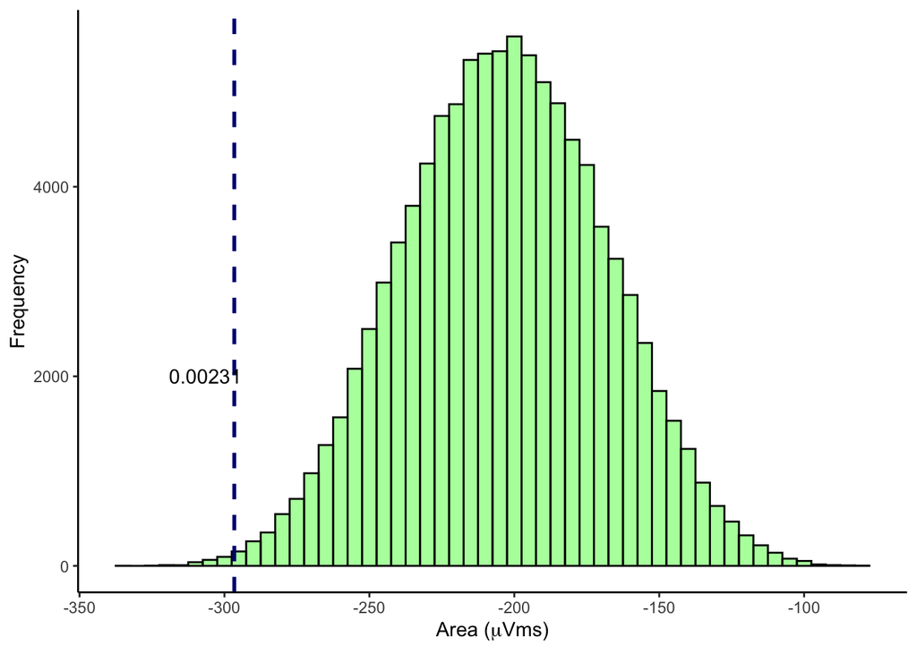

```
##
## $`SPCN, No Distractor, Valid Cue`
```

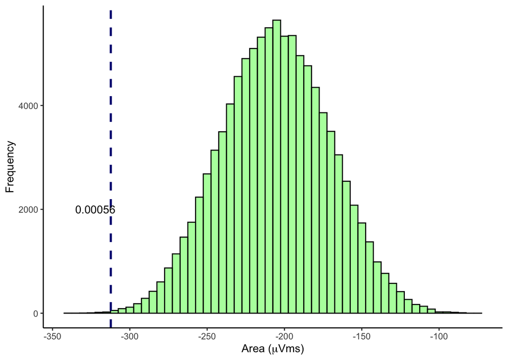

```
##
## $`SPCN, Salient Target, Valid Cue`
```

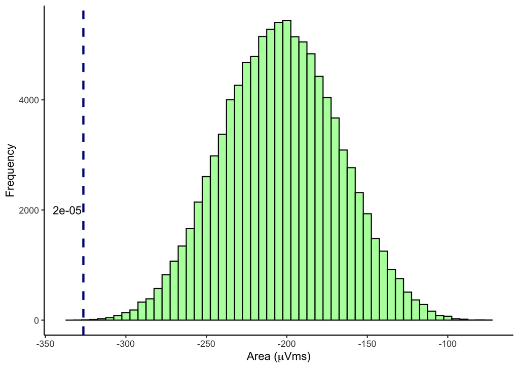

```
##
## $`SPCN, Lateral Target, Neutral Cue`
```

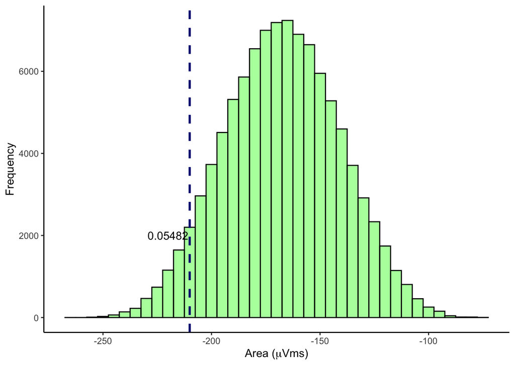

```
##
## $`SPCN, No Distractor, Neutral Cue`
```

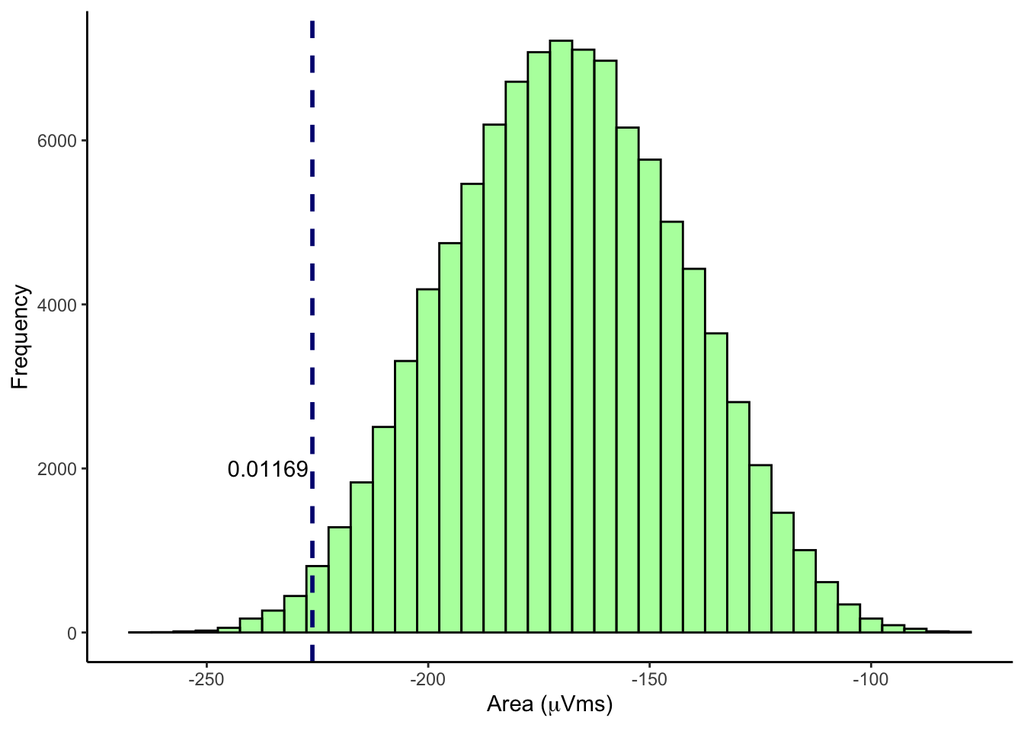

```
##
## $`SPCN, Salient Target, Neutral Cue`
```

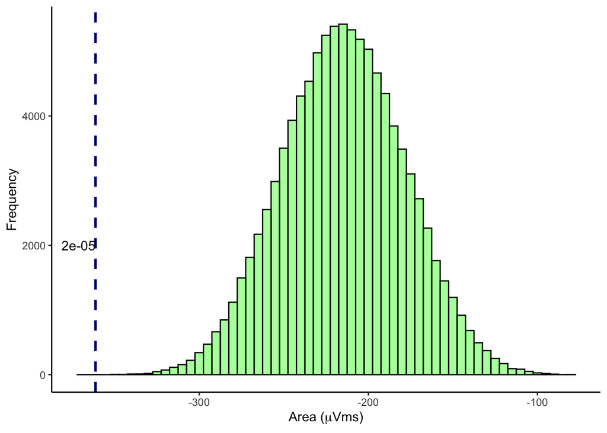

```r
#loading data
#Experiment 1
setwd("~/Desktop/MAC_project/Exp1/EEG/DW")
e1_RLpcN_LT_V <- read.delim("rlocked_AllCorrValidCues_DistrV_TargBL_avg_LRP_Peaks_600N.txt",header=TRUE,sep = "")
e1_RLpcN_LT_V_I <- read.delim("RLpcN_Valid_LateralTarget_2segP.txt",header=TRUE,sep = "")
e1_RLpcN_ND_V <- read.delim("rlocked_AllCorrValidCues_NoDist_TargBL_avg_LRP_Peaks_600N.txt",header=TRUE,sep = "")
e1_RLpcN_ND_V_I <- read.delim("RLpcN_Valid_NoDist_2segP.txt",header=TRUE,sep = "")
e1_RLpcN_ST_V <- read.delim("rlocked_AllCorrValidCues_SalientTarget_TargBL_avg_LRP_Peaks_600N.txt",header=TRUE,sep = "")
e1_RLpcN_ST_V_I <- read.delim("RLpcN_Valid_SalientTarget_2segP.txt",header=TRUE,sep = "")
e1_RLpcN_LT_N <- read.delim("rlocked_AllCorrNeutralCues_DistrV_TargBL_avg_LRP_Peaks_600N.txt",header=TRUE,sep = "")
e1_RLpcN_LT_N_I <- read.delim("RLpcN_Neutral_LateralTarget_2segP.txt",header=TRUE,sep = "")
e1_RLpcN_ND_N <- read.delim("rlocked_AllCorrNeutralCues_NoDist_TargBL_avg_LRP_Peaks_600N.txt",header=TRUE,sep = "")
e1_RLpcN_ND_N_I <- read.delim("RLpcN_Neutral_NoDist_2segP.txt",header=TRUE,sep = "")
e1_RLpcN_ST_N <- read.delim("rlocked_AllCorrNeutralCues_SalientTarget_TargBL_avg_LRP_Peaks_600N.txt",header=TRUE,sep = "")
e1_RLpcN_ST_N_I <- read.delim("RLpcN_Neutral_SalientTarget_2segP.txt",header=TRUE,sep = "")
##amplitude1 = amplitude of early RLpcN portion, amplitude2 = amplitude of ##late RLpcN portion
names(e1_RLpcN_LT_V)[2] <- "amplitude1"
names(e1_RLpcN_LT_V_I)[2] <- "amplitude1"
names(e1_RLpcN_ND_V)[2] <- "amplitude1"
names(e1_RLpcN_ND_V_I)[2] <- "amplitude1"
names(e1_RLpcN_ST_V)[2] <- "amplitude1"
names(e1_RLpcN_ST_V_I)[2] <- "amplitude1"
names(e1_RLpcN_LT_N)[2] <- "amplitude1"
names(e1_RLpcN_LT_N_I)[2] <- "amplitude1"
names(e1_RLpcN_ND_N)[2] <- "amplitude1"
names(e1_RLpcN_ND_N_I)[2] <- "amplitude1"
names(e1_RLpcN_ST_N)[2] <- "amplitude1"
names(e1_RLpcN_ST_N_I)[2] <- "amplitude1"

names(e1_RLpcN_LT_V)[3] <- "amplitude2"
names(e1_RLpcN_LT_V_I)[3] <- "amplitude2"
names(e1_RLpcN_ND_V)[3] <- "amplitude2"
names(e1_RLpcN_ND_V_I)[3] <- "amplitude2"
names(e1_RLpcN_ST_V)[3] <- "amplitude2"
names(e1_RLpcN_ST_V_I)[3] <- "amplitude2"
names(e1_RLpcN_LT_N)[3] <- "amplitude2"
names(e1_RLpcN_LT_N_I)[3] <- "amplitude2"
names(e1_RLpcN_ND_N)[3] <- "amplitude2"
names(e1_RLpcN_ND_N_I)[3] <- "amplitude2"
names(e1_RLpcN_ST_N)[3] <- "amplitude2"
names(e1_RLpcN_ST_N_I)[3] <- "amplitude2"

#converting positive to negative values
e1_RLpcN_LT_V_I$amplitude1 <- e1_RLpcN_LT_V_I$amplitude1*(-1)
e1_RLpcN_ND_V_I$amplitude1 <- e1_RLpcN_ND_V_I$amplitude1*(-1)
e1_RLpcN_ST_V_I$amplitude1 <- e1_RLpcN_ST_V_I$amplitude1*(-1)
e1_RLpcN_LT_N_I$amplitude1 <- e1_RLpcN_LT_N_I$amplitude1*(-1)
e1_RLpcN_ND_N_I$amplitude1 <- e1_RLpcN_ND_N_I$amplitude1*(-1)
e1_RLpcN_ST_N_I$amplitude1 <- e1_RLpcN_ST_N_I$amplitude1*(-1)

e1_RLpcN_LT_V_I$amplitude2 <- e1_RLpcN_LT_V_I$amplitude2*(-1)
e1_RLpcN_ND_V_I$amplitude2 <- e1_RLpcN_ND_V_I$amplitude2*(-1)
e1_RLpcN_ST_V_I$amplitude2 <- e1_RLpcN_ST_V_I$amplitude2*(-1)
e1_RLpcN_LT_N_I$amplitude2 <- e1_RLpcN_LT_N_I$amplitude2*(-1)
e1_RLpcN_ND_N_I$amplitude2 <- e1_RLpcN_ND_N_I$amplitude2*(-1)
e1_RLpcN_ST_N_I$amplitude2 <- e1_RLpcN_ST_N_I$amplitude2*(-1)

#combining real (contra-ipsi) and inverted (ipsi-contra) values into one pool for sampling
e1_RLpcN_LT_V_pooled_1 <- rbind(select(e1_RLpcN_LT_V,amplitude1),select(e1_RLpcN_LT_V_I,amplitude1))
e1_RLpcN_ND_V_pooled_1 <- rbind(select(e1_RLpcN_ND_V,amplitude1),select(e1_RLpcN_ND_V_I,amplitude1))
e1_RLpcN_ST_V_pooled_1 <- rbind(select(e1_RLpcN_ST_V,amplitude1),select(e1_RLpcN_ST_V_I,amplitude1))
e1_RLpcN_LT_N_pooled_1 <- rbind(select(e1_RLpcN_LT_N,amplitude1),select(e1_RLpcN_LT_N_I,amplitude1))
e1_RLpcN_ND_N_pooled_1 <- rbind(select(e1_RLpcN_ND_N,amplitude1),select(e1_RLpcN_ND_N_I,amplitude1))
e1_RLpcN_ST_N_pooled_1 <- rbind(select(e1_RLpcN_ST_N,amplitude1),select(e1_RLpcN_ST_N_I,amplitude1))

e1_RLpcN_LT_V_pooled_2 <- rbind(select(e1_RLpcN_LT_V,amplitude2),select(e1_RLpcN_LT_V_I,amplitude2))
e1_RLpcN_ND_V_pooled_2 <- rbind(select(e1_RLpcN_ND_V,amplitude2),select(e1_RLpcN_ND_V_I,amplitude2))
e1_RLpcN_ST_V_pooled_2 <- rbind(select(e1_RLpcN_ST_V,amplitude2),select(e1_RLpcN_ST_V_I,amplitude2))
e1_RLpcN_LT_N_pooled_2 <- rbind(select(e1_RLpcN_LT_N,amplitude2),select(e1_RLpcN_LT_N_I,amplitude2))
e1_RLpcN_ND_N_pooled_2 <- rbind(select(e1_RLpcN_ND_N,amplitude2),select(e1_RLpcN_ND_N_I,amplitude2))
e1_RLpcN_ST_N_pooled_2 <- rbind(select(e1_RLpcN_ST_N,amplitude2),select(e1_RLpcN_ST_N_I,amplitude2))

#Experiment 2
setwd("~/Desktop/MAC_project/Exp1a/EEG/DW")
e2_RLpcN_LT_V <- read.delim("rlocked_AllCorrValidCues_DistrV_TargBL_avg_LRP_Peaks_600N.txt",header=TRUE,sep = "")
e2_RLpcN_LT_V_I <- read.delim("RLpcN_Valid_LateralTarget_2segP.txt",header=TRUE,sep = "")
e2_RLpcN_ND_V <- read.delim("rlocked_AllCorrValidCues_NoDist_TargBL_avg_LRP_Peaks_600N.txt",header=TRUE,sep = "")
e2_RLpcN_ND_V_I <- read.delim("RLpcN_Valid_NoDist_2segP.txt",header=TRUE,sep = "")
e2_RLpcN_ST_V <- read.delim("rlocked_AllCorrValidCues_SalientTarget_TargBL_avg_LRP_Peaks_600N.txt",header=TRUE,sep = "")
e2_RLpcN_ST_V_I <- read.delim("RLpcN_Valid_SalientTarget_2segP.txt",header=TRUE,sep = "")
e2_RLpcN_LT_N <- read.delim("rlocked_AllCorrNeutralCues_DistrV_TargBL_avg_LRP_Peaks_600N.txt",header=TRUE,sep = "")
e2_RLpcN_LT_N_I <- read.delim("RLpcN_Neutral_LateralTarget_2segP.txt",header=TRUE,sep = "")
e2_RLpcN_ND_N <- read.delim("rlocked_AllCorrNeutralCues_NoDist_TargBL_avg_LRP_Peaks_600N.txt",header=TRUE,sep = "")
e2_RLpcN_ND_N_I <- read.delim("RLpcN_Neutral_NoDist_2segP.txt",header=TRUE,sep = "")
e2_RLpcN_ST_N <- read.delim("rlocked_AllCorrNeutralCues_SalientTarget_TargBL_avg_LRP_Peaks_600N.txt",header=TRUE,sep = "")
e2_RLpcN_ST_N_I <- read.delim("RLpcN_Neutral_SalientTarget_2segP.txt",header=TRUE,sep = "")
##amplitude1 = amplitude of early RLpcN portion, amplitude2 = amplitude of ##late RLpcN portion
names(e2_RLpcN_LT_V)[2] <- "amplitude1"
names(e2_RLpcN_LT_V_I)[2] <- "amplitude1"
names(e2_RLpcN_ND_V)[2] <- "amplitude1"
names(e2_RLpcN_ND_V_I)[2] <- "amplitude1"
names(e2_RLpcN_ST_V)[2] <- "amplitude1"
names(e2_RLpcN_ST_V_I)[2] <- "amplitude1"
names(e2_RLpcN_LT_N)[2] <- "amplitude1"
names(e2_RLpcN_LT_N_I)[2] <- "amplitude1"
names(e2_RLpcN_ND_N)[2] <- "amplitude1"
names(e2_RLpcN_ND_N_I)[2] <- "amplitude1"
names(e2_RLpcN_ST_N)[2] <- "amplitude1"
names(e2_RLpcN_ST_N_I)[2] <- "amplitude1"

names(e2_RLpcN_LT_V)[3] <- "amplitude2"
names(e2_RLpcN_LT_V_I)[3] <- "amplitude2"
names(e2_RLpcN_ND_V)[3] <- "amplitude2"
names(e2_RLpcN_ND_V_I)[3] <- "amplitude2"
names(e2_RLpcN_ST_V)[3] <- "amplitude2"
names(e2_RLpcN_ST_V_I)[3] <- "amplitude2"
names(e2_RLpcN_LT_N)[3] <- "amplitude2"
names(e2_RLpcN_LT_N_I)[3] <- "amplitude2"
names(e2_RLpcN_ND_N)[3] <- "amplitude2"
names(e2_RLpcN_ND_N_I)[3] <- "amplitude2"
names(e2_RLpcN_ST_N)[3] <- "amplitude2"
names(e2_RLpcN_ST_N_I)[3] <- "amplitude2"

#converting positive to negative values
e2_RLpcN_LT_V_I$amplitude1 <- e2_RLpcN_LT_V_I$amplitude1*(-1)
e2_RLpcN_ND_V_I$amplitude1 <- e2_RLpcN_ND_V_I$amplitude1*(-1)
e2_RLpcN_ST_V_I$amplitude1 <- e2_RLpcN_ST_V_I$amplitude1*(-1)
e2_RLpcN_LT_N_I$amplitude1 <- e2_RLpcN_LT_N_I$amplitude1*(-1)
e2_RLpcN_ND_N_I$amplitude1 <- e2_RLpcN_ND_N_I$amplitude1*(-1)
e2_RLpcN_ST_N_I$amplitude1 <- e2_RLpcN_ST_N_I$amplitude1*(-1)

e2_RLpcN_LT_V_I$amplitude2 <- e2_RLpcN_LT_V_I$amplitude2*(-1)
e2_RLpcN_ND_V_I$amplitude2 <- e2_RLpcN_ND_V_I$amplitude2*(-1)
e2_RLpcN_ST_V_I$amplitude2 <- e2_RLpcN_ST_V_I$amplitude2*(-1)
e2_RLpcN_LT_N_I$amplitude2 <- e2_RLpcN_LT_N_I$amplitude2*(-1)
e2_RLpcN_ND_N_I$amplitude2 <- e2_RLpcN_ND_N_I$amplitude2*(-1)
e2_RLpcN_ST_N_I$amplitude2 <- e2_RLpcN_ST_N_I$amplitude2*(-1)

#combining real (contra-ipsi) and inverted (ipsi-contra) values into one pool for sampling
e2_RLpcN_LT_V_pooled_1 <- rbind(select(e2_RLpcN_LT_V,amplitude1),select(e2_RLpcN_LT_V_I,amplitude1))
e2_RLpcN_ND_V_pooled_1 <- rbind(select(e2_RLpcN_ND_V,amplitude1),select(e2_RLpcN_ND_V_I,amplitude1))
e2_RLpcN_ST_V_pooled_1 <- rbind(select(e2_RLpcN_ST_V,amplitude1),select(e2_RLpcN_ST_V_I,amplitude1))
e2_RLpcN_LT_N_pooled_1 <- rbind(select(e2_RLpcN_LT_N,amplitude1),select(e2_RLpcN_LT_N_I,amplitude1))
e2_RLpcN_ND_N_pooled_1 <- rbind(select(e2_RLpcN_ND_N,amplitude1),select(e2_RLpcN_ND_N_I,amplitude1))
e2_RLpcN_ST_N_pooled_1 <- rbind(select(e2_RLpcN_ST_N,amplitude1),select(e2_RLpcN_ST_N_I,amplitude1))

e2_RLpcN_LT_V_pooled_2 <- rbind(select(e2_RLpcN_LT_V,amplitude2),select(e2_RLpcN_LT_V_I,amplitude2))
e2_RLpcN_ND_V_pooled_2 <- rbind(select(e2_RLpcN_ND_V,amplitude2),select(e2_RLpcN_ND_V_I,amplitude2))
e2_RLpcN_ST_V_pooled_2 <- rbind(select(e2_RLpcN_ST_V,amplitude2),select(e2_RLpcN_ST_V_I,amplitude2))
e2_RLpcN_LT_N_pooled_2 <- rbind(select(e2_RLpcN_LT_N,amplitude2),select(e2_RLpcN_LT_N_I,amplitude2))
e2_RLpcN_ND_N_pooled_2 <- rbind(select(e2_RLpcN_ND_N,amplitude2),select(e2_RLpcN_ND_N_I,amplitude2))
e2_RLpcN_ST_N_pooled_2 <- rbind(select(e2_RLpcN_ST_N,amplitude2),select(e2_RLpcN_ST_N_I,amplitude2))
```

permutation tests - RLpcN experiment 1

```
## $`RLpcN, Lateral Target, Valid Cue, 1st`
```

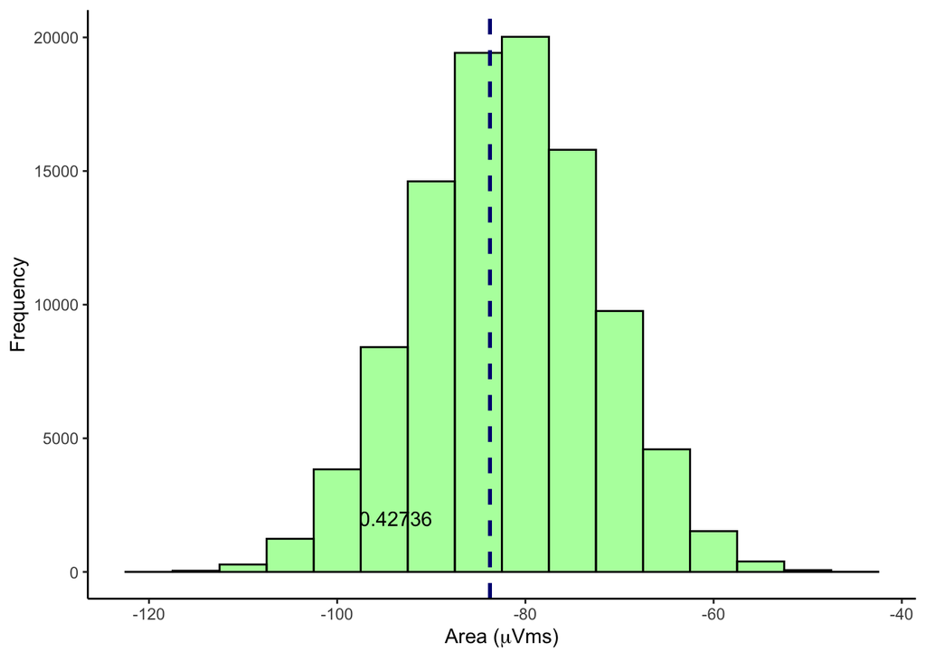

```
##
## $`RLpcN, No Distractor, Valid Cue, 1st`
```

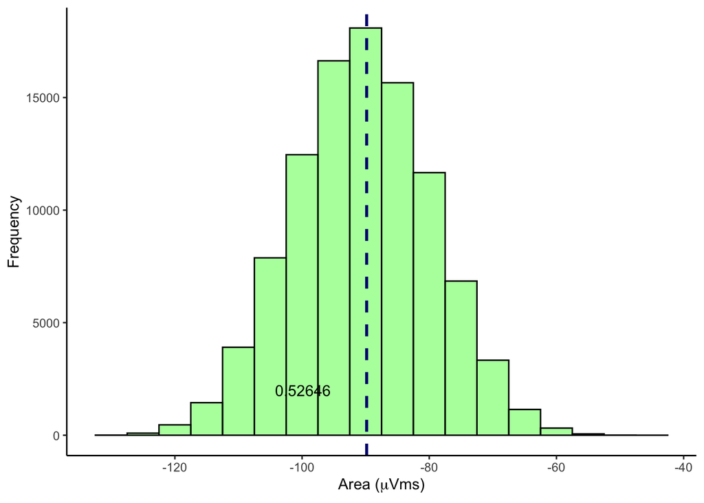

```
##
## $`RLpcN, Salient Target, Valid Cue, 1st`
```

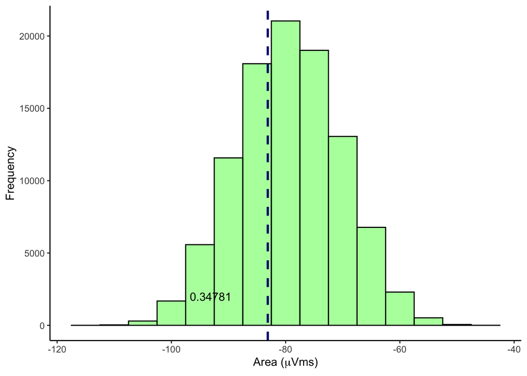

```
##
## $`RLpcN, Lateral Target, Neutral Cue, 1st`
```

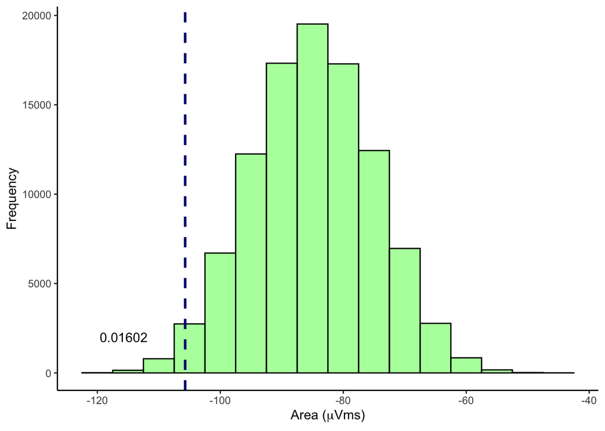

```
##
## $`RLpcN, No Distractor, Neutral Cue, 1st`
```

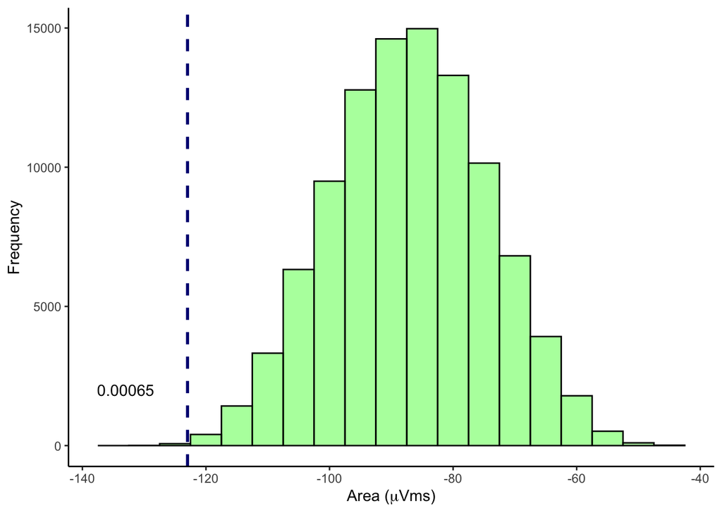

```
##
## $`RLpcN, Salient Target, Neutral Cue, 1st`
```

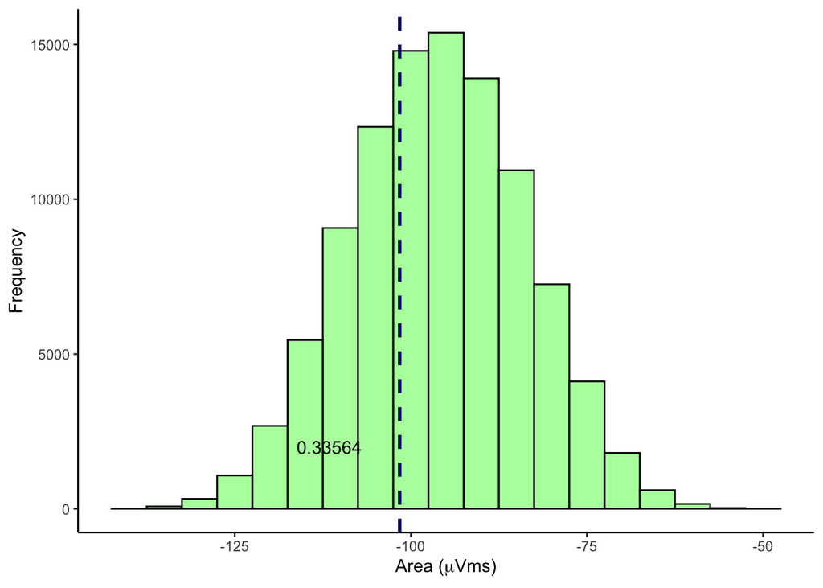

```
##
## $`RLpcN, Lateral Target, Valid Cue, 2nd`
```

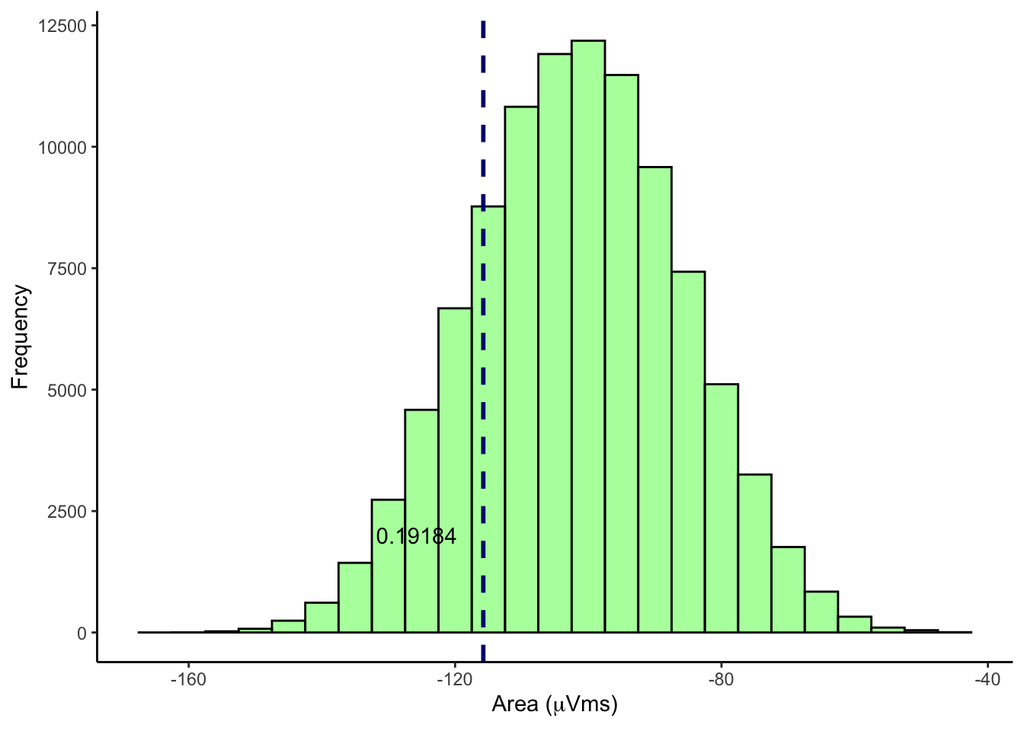

```
##
## $`RLpcN, No Distractor, Valid Cue, 2nd`
```

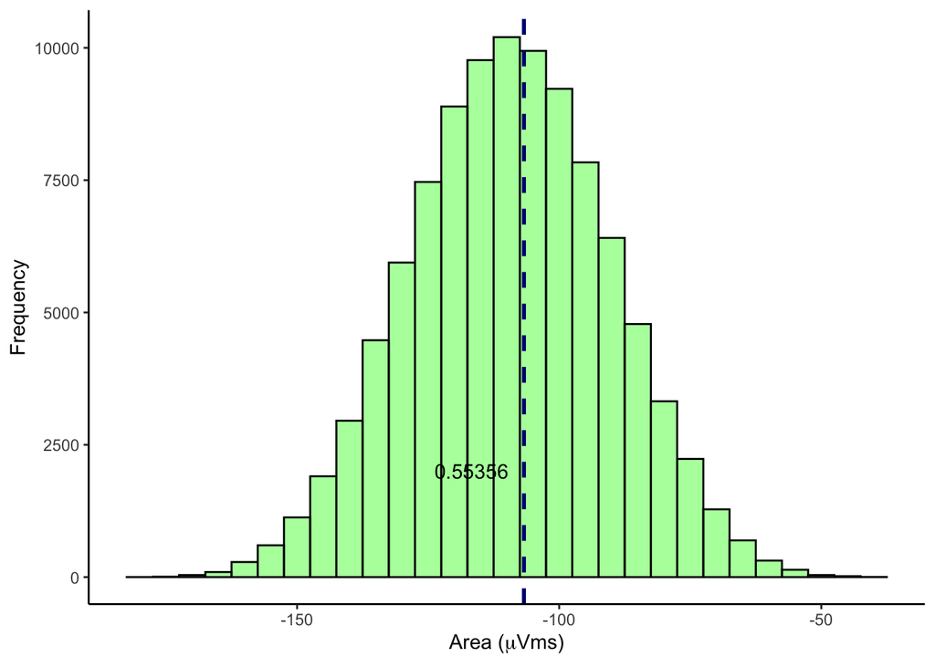

```
##
## $`RLpcN, Salient Target, Valid Cue, 2nd`
```

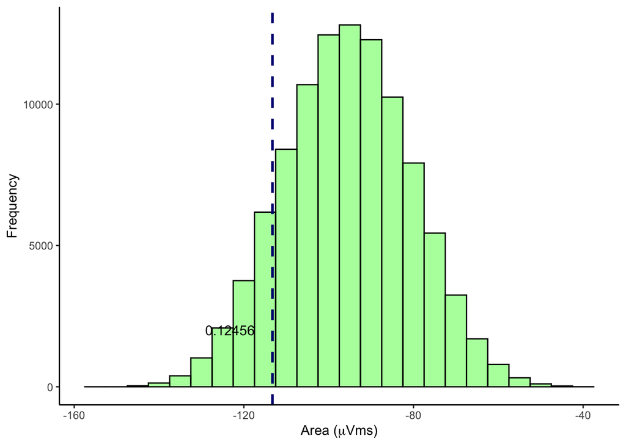

```
##
## $`RLpcN, Lateral Target, Neutral Cue, 2nd`
```

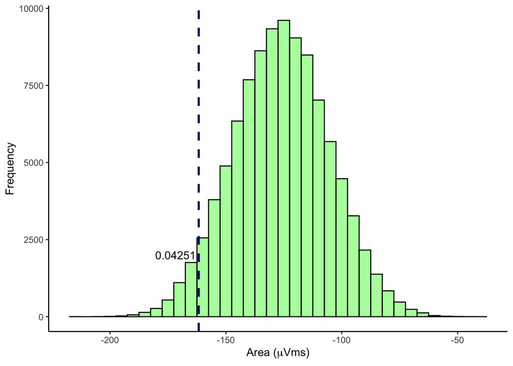

```
##
## $`RLpcN, No Distractor, Neutral Cue, 2nd`
```

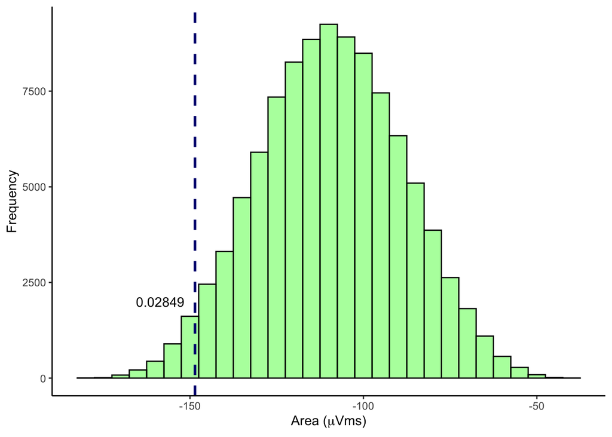

```
##
## $`RLpcN, Salient Target, Neutral Cue, 2nd`
```

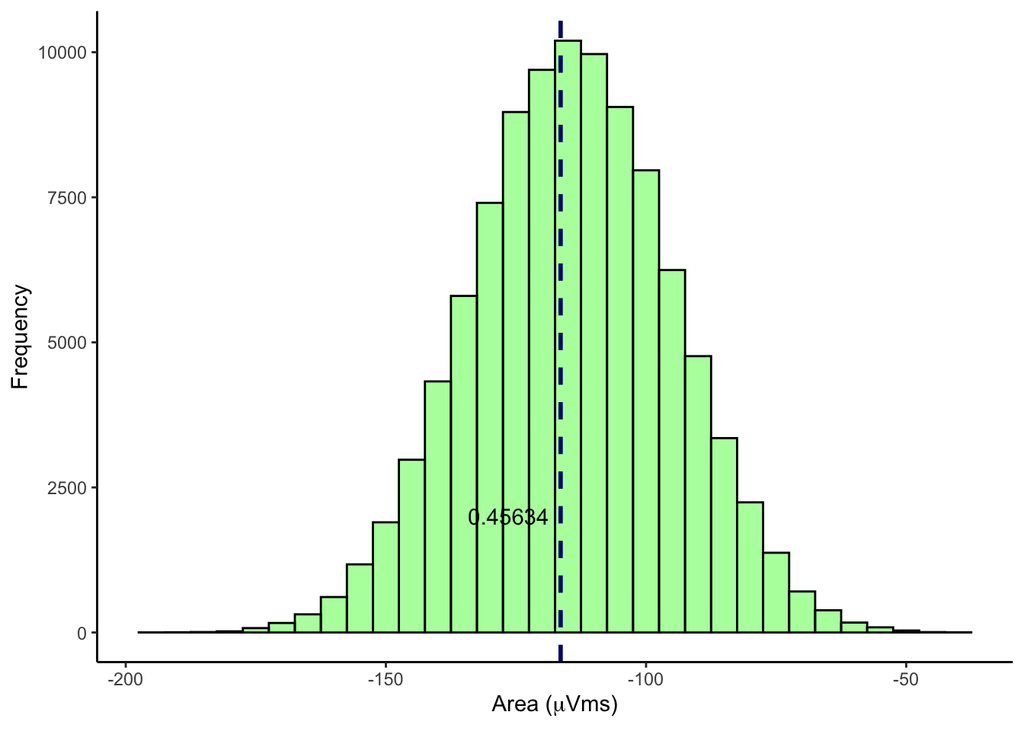

permutation tests - RLpcN experiment 2

```
## $`RLpcN, Lateral Target, Valid Cue, 1st`
```

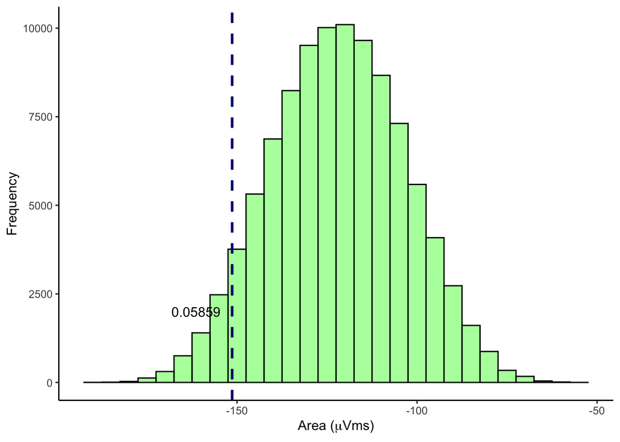

```
##
## $`RLpcN, No Distractor, Valid Cue, 1st`
```

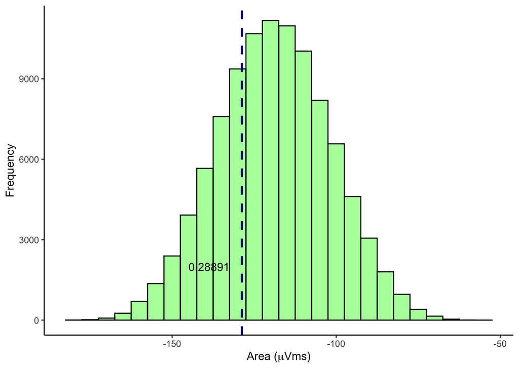

```
##
## $`RLpcN, Salient Target, Valid Cue, 1st`
```

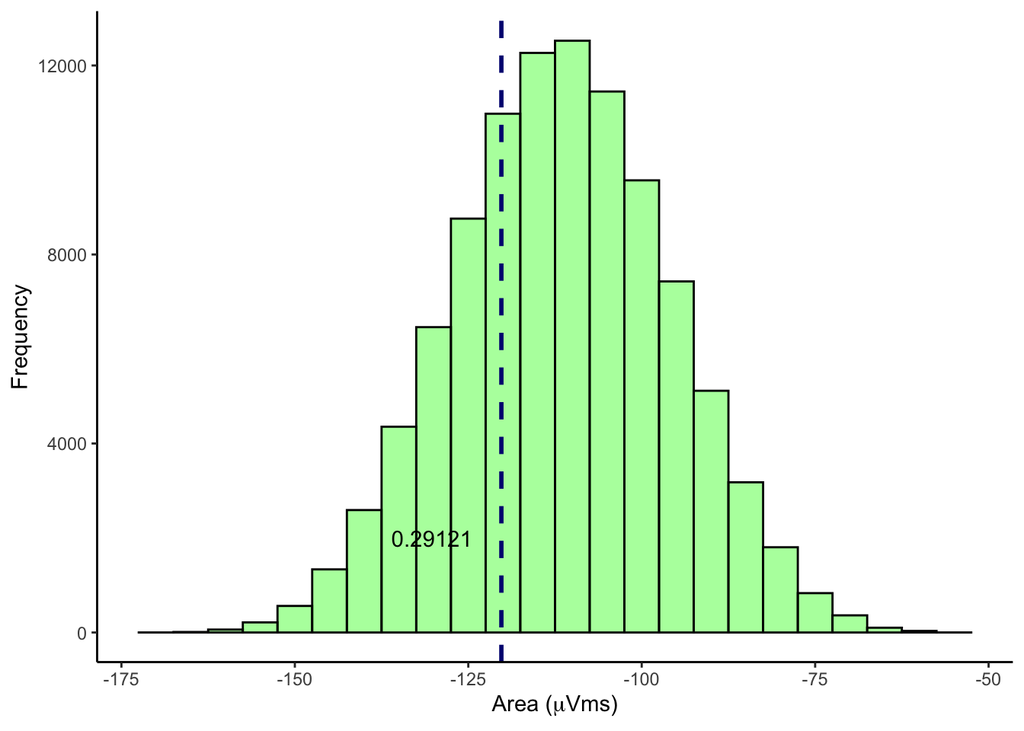

```
##
## $`RLpcN, Lateral Target, Neutral Cue, 1st`
```

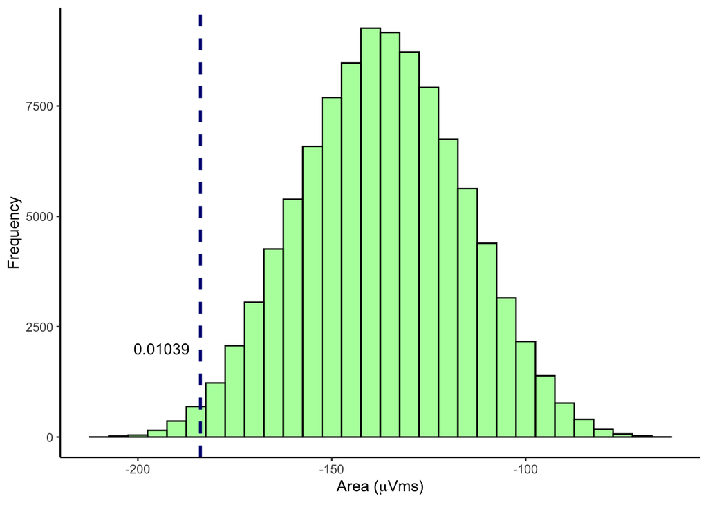

```
##
## $`RLpcN, No Distractor, Neutral Cue, 1st`
```

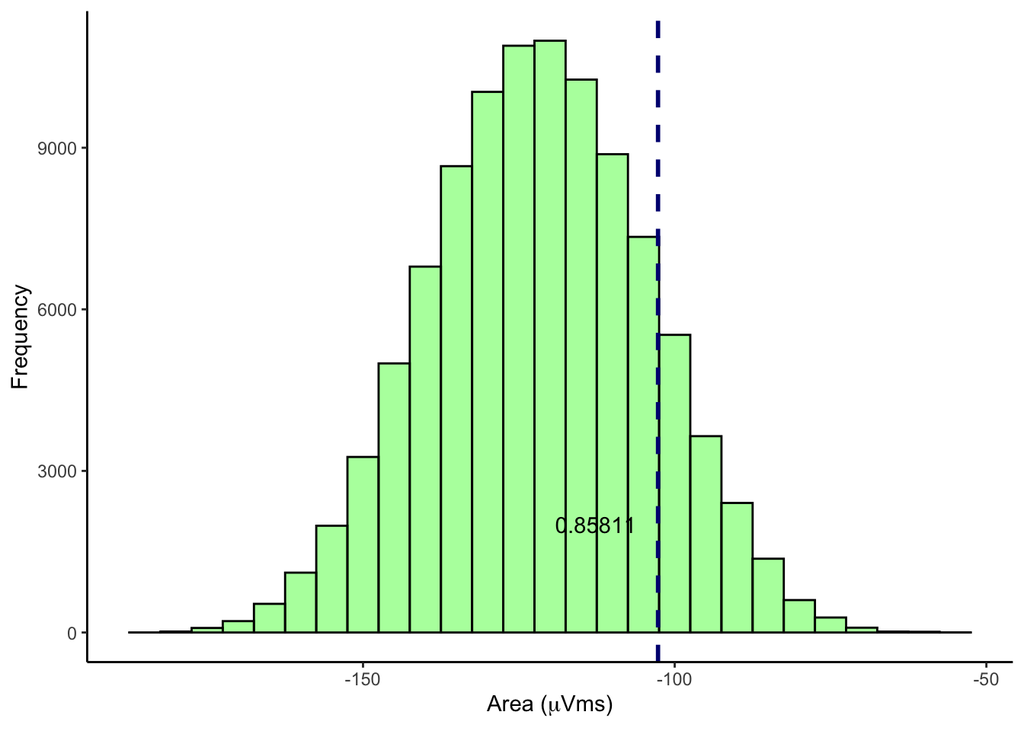

```
##
## $`RLpcN, Salient Target, Neutral Cue, 1st`
```

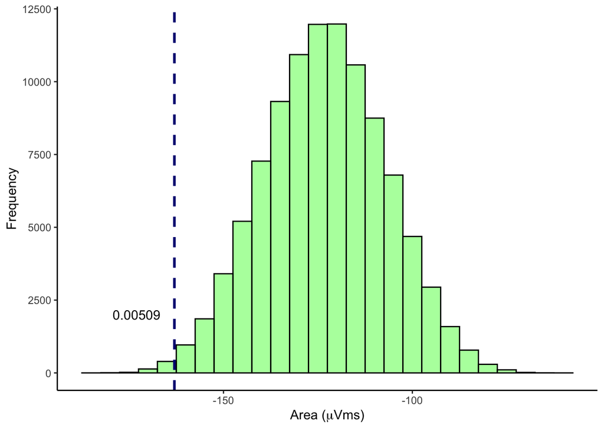

```
##
## $`RLpcN, Lateral Target, Valid Cue, 2nd`
```

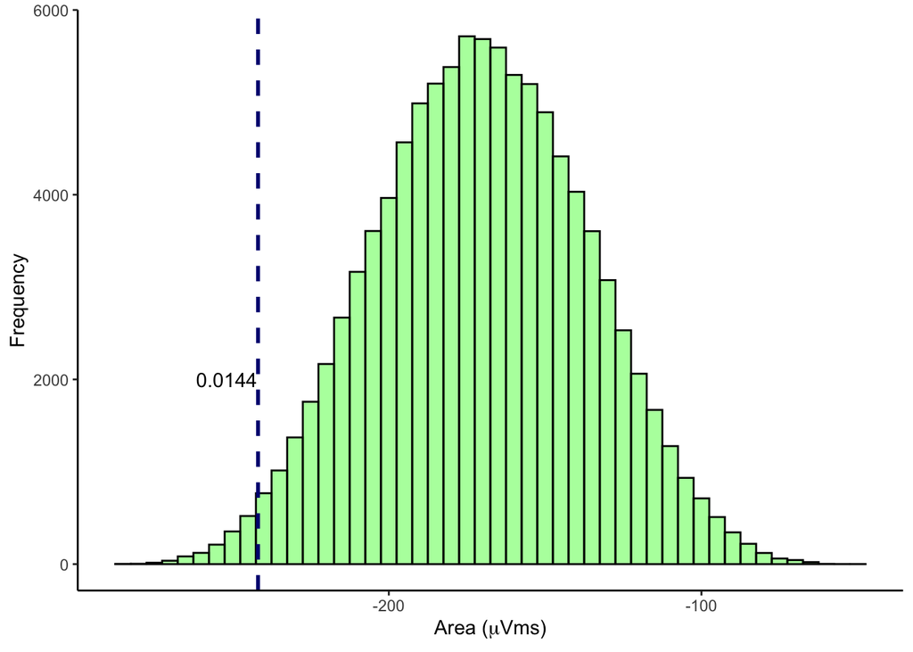

```
##
## $`RLpcN, No Distractor, Valid Cue, 2nd`
```

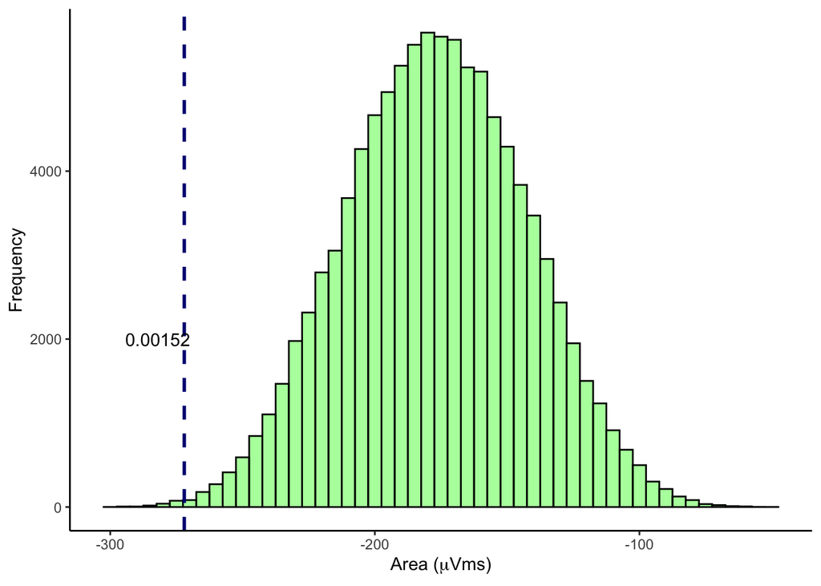

```
##
## $`RLpcN, Salient Target, Valid Cue, 2nd`
```